# Human Activity Recognition with Weight Lifting

# Executive Summary

# Background

Using devices such as Jawbone Up, Nike FuelBand, and Fitbit it is now possible to collect a large amount of data about personal activity relatively inexpensively. These type of devices are part of the quantified self movement – a group of enthusiasts who take measurements about themselves regularly to improve their health, to find patterns in their behavior, or because they are tech geeks. One thing that people regularly do is quantify how much of a particular activity they do, but they rarely quantify how well they do it. More information is abailable from this [website](http://web.archive.org/web/20161224072740/http:/groupware.les.inf.puc-rio.br/har)

In this report, we will use data from accelerometers on the belt, forearm, arm, and dumbbell of 6 participants. They were asked to perform barbell lifts correctly and incorrectly in 5 different ways.

# Data

Training data is available [here](https://d396qusza40orc.cloudfront.net/predmachlearn/pml-training.csv)

Test data is available [here](https://d396qusza40orc.cloudfront.net/predmachlearn/pml-testing.csv)

```r
# check if exists, then download from sources
if (!file.exists("training_data.csv")){
  download.file("https://d396qusza40orc.cloudfront.net/predmachlearn/pml-training.csv", "training_data.csv")

}

if (!file.exists("training_data.csv")){
  download.file("https://d396qusza40orc.cloudfront.net/predmachlearn/pml-testing.csv", "testing_data.csv")
}

#import data
training <- read_csv("training_data.csv")
testing <- read_csv("testing_data.csv")
```

```r
training$classe <- as.factor(training$classe)
```

We find that there are multiple variables that have no entries at all. We will first remove these variables.

We also find that `...1` is simply a reference number for each observation, and should not be included either.

Other columns we will not include are `user_name` and datetime variables. As this may include bias depending on simply who and when a participant decided to perform incorrectly.

```r
# obtain columns with no observations
col_na <- colnames(training)[colSums(is.na(training)) > 0]
training <- select(training, -c(all_of(col_na)))
training <- select(training, -c("...1", "new_window",
                                "num_window", "user_name",
                                "raw_timestamp_part_1",
                                "raw_timestamp_part_2",
                                "cvtd_timestamp"))
```

```r
# get columns where the variance of that column is above #
trainVar <- training %>% summarise_if(is.numeric, var)

varLevel <- which(trainVar >= 100, arr.ind = T)

col_selection <- names(trainVar[varLevel[,2]])

# choosing only relevant columns
training <- training[, c(col_selection, "classe")]
```

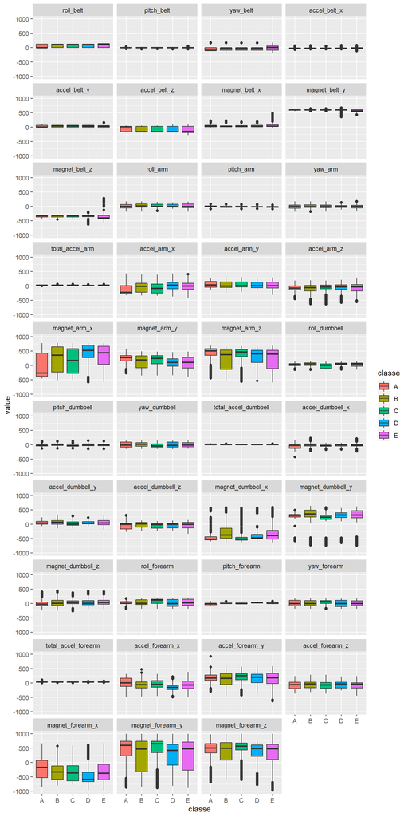

```r
plot1 <- function(df){

  df_long <- melt(df, id.vars = "classe")

  df_long$classe <- factor(df_long$classe,
                           levels = c("A", "B", "C", "D", "E"))

  ggplot(data = df_long, aes(x = classe,
                                 y = value,
                                 fill = classe)) +
    ylim(-1000, 1000)+
    geom_boxplot() +
    facet_wrap(. ~ variable, nrow = 10)
}
plot1(training)
```

# Modelling

Now that we have trimmed the variables down to the most relevant ones, we can now choose some models and fit for each.

With `40` variables at this stage, with various magnitudes, we’ll opt to utilise the following models to minimise bias in our combined model.

- Random Forests
- Radial Basis Functions
- Support Vector Machine
- Gradient Boosted Classifier

Firstly, we will have to split our training data. We will do a 3-split as we want to also stack our models.

*Note: These models have been stored in “ProjectModels.RData” to save computing efforts.*

```r
if (!file.exists("ProjectModels.RData")){
    download.file("https://github.com/JL173/PracticalMachineLearningProject/raw/main/ProjectModels.RData",
                  "ProjectModels.RData")
    }
load("ProjectModels.RData")

# wRF = Random Forest Model
# wRBF = Radial Basis Function Model
# wSVM = Support Vector Machine Model
# wCOMB = combined model using Random Forest on other model predictions
```

```r
# splitting the data
set.seed(17373)

trainIndex <- createDataPartition(training$classe,
                                  p = .8, list = FALSE, times = 1)

wTrain_ <- training[trainIndex,]
wTest <- training[-trainIndex,]

# split test further to create a validation set

valIndex <- createDataPartition(wTrain_$classe,
                                p = .7, list = FALSE, times = 1)

wTrain <- wTrain_[valIndex,]
wVal <- wTrain_[-valIndex,]

print(c(dim(wTrain), dim(wVal), dim(wTest)))
```

```
## [1] 10992    40  4707    40  3923    40
```

This split gives us 10992 rows for Training, 4707 for validating our stacked models, and 3923 for testing.

```r
# 5-fold cross-validaiton
set.seed(37)

ctrl <- trainControl(method = "cv", number = 3)
RFgrid <- expand.grid(mtry = c(2:4))
RBFgrid <- expand.grid(C = c(0.01, 0.03, 0.1, 0.3, 1.0, 3.0),
                       sigma = c(0.001, 0.003, 0.01, 0.03, 0.1, 0.3))
SVMgrid <- expand.grid(C = c(0.01, 0.03, 0.1, 0.3, 1.0, 3.0))
```

```r
cl <- makePSOCKcluster(5) # init parallel processing
registerDoParallel(cl)

wRF <- train(classe ~ ., method = "rf", tfControl = ctrl,
             preProcess = c("center", "scale"), tuneGrid = RFgrid,
             data = wTrain)

stopCluster(cl) # stop parallel processing
```

```r
pred_wRF <- predict(wRF, newdata = wTest)

confusionMatrix(pred_wRF, wTest$classe)
```

```
## Confusion Matrix and Statistics
##
##           Reference
## Prediction    A    B    C    D    E
##          A 1112   10    0    0    0
##          B    4  744    3    0    0
##          C    0    4  680    9    0
##          D    0    1    1  634    3
##          E    0    0    0    0  718
##
## Overall Statistics
##
##                Accuracy : 0.9911
##                  95% CI : (0.9876, 0.9938)
##     No Information Rate : 0.2845
##     P-Value [Acc > NIR] : < 2.2e-16
##
##                   Kappa : 0.9887
##
##  Mcnemar's Test P-Value : NA
##
## Statistics by Class:
##
##                      Class: A Class: B Class: C Class: D Class: E
## Sensitivity            0.9964   0.9802   0.9942   0.9860   0.9958
## Specificity            0.9964   0.9978   0.9960   0.9985   1.0000
## Pos Pred Value         0.9911   0.9907   0.9812   0.9922   1.0000
## Neg Pred Value         0.9986   0.9953   0.9988   0.9973   0.9991
## Prevalence             0.2845   0.1935   0.1744   0.1639   0.1838
## Detection Rate         0.2835   0.1897   0.1733   0.1616   0.1830
## Detection Prevalence   0.2860   0.1914   0.1767   0.1629   0.1830
## Balanced Accuracy      0.9964   0.9890   0.9951   0.9922   0.9979
```

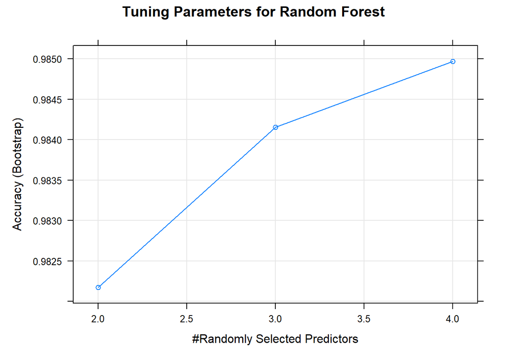

```r
#png(filename = "tuning_plot_rf.png", width = 600, height = 400)
plot(wRF, main = "Tuning Parameters for Random Forest")
```

```r
#dev.off()
```

```r
cl <- makePSOCKcluster(5) # init parallel processing
registerDoParallel(cl)

wRBF <- train(classe ~ ., method = "svmRadial", tfControl = ctrl,
              preProcess = c("center", "scale"), tuneGrid = RBFgrid,
              tuneLength = 10, data = wTrain)

stopCluster(cl) # stop parallel processing
```

```r
pred_wRBF <- predict(wRBF, newdata = wTest)

confusionMatrix(pred_wRBF, wTest$classe)
```

```
## Confusion Matrix and Statistics
##
##           Reference
## Prediction    A    B    C    D    E
##          A 1107   20    0    1    0
##          B    7  729    8    0    2
##          C    0    7  674   33    0
##          D    1    0    2  604   10
##          E    1    3    0    5  709
##
## Overall Statistics
##
##                Accuracy : 0.9745
##                  95% CI : (0.9691, 0.9792)
##     No Information Rate : 0.2845
##     P-Value [Acc > NIR] : < 2.2e-16
##
##                   Kappa : 0.9677
##
##  Mcnemar's Test P-Value : NA
##
## Statistics by Class:
##
##                      Class: A Class: B Class: C Class: D Class: E
## Sensitivity            0.9919   0.9605   0.9854   0.9393   0.9834
## Specificity            0.9925   0.9946   0.9877   0.9960   0.9972
## Pos Pred Value         0.9814   0.9772   0.9440   0.9789   0.9875
## Neg Pred Value         0.9968   0.9906   0.9969   0.9882   0.9963
## Prevalence             0.2845   0.1935   0.1744   0.1639   0.1838
## Detection Rate         0.2822   0.1858   0.1718   0.1540   0.1807
## Detection Prevalence   0.2875   0.1902   0.1820   0.1573   0.1830
## Balanced Accuracy      0.9922   0.9776   0.9865   0.9677   0.9903
```

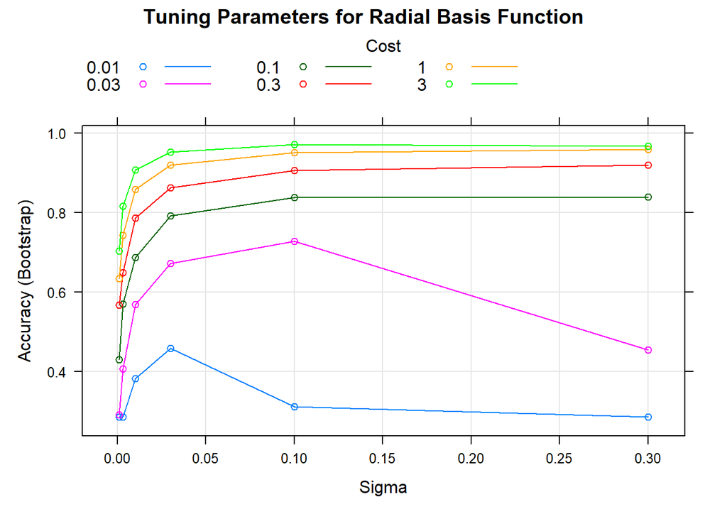

```r
#png(filename = "tuning_plot_rbf.png", width = 600, height = 400)
plot(wRBF, main = "Tuning Parameters for Radial Basis Function")
```

```r
#dev.off()
```

```r
cl <- makePSOCKcluster(5) # init parallel processing
registerDoParallel(cl)

wSVM <- train(classe ~ ., method = "svmLinear",
              tfControl = ctrl,
              preProcess = c("center", "scale"),
              tuneGrid = SVMgrid,
              tuneLength = 10, data = wTrain)

stopCluster(cl) # stop parallel processing
```

```r
pred_wSVM <- predict(wSVM, newdata = wTest)

confusionMatrix(pred_wSVM, wTest$classe)
```

```
## Confusion Matrix and Statistics
##
##           Reference
## Prediction    A    B    C    D    E
##          A 1008   98   45   36   45
##          B   24  553   59   24   86
##          C   26   49  544   63   37
##          D   50   10   23  482   44
##          E    8   49   13   38  509
##
## Overall Statistics
##
##                Accuracy : 0.7892
##                  95% CI : (0.7761, 0.8019)
##     No Information Rate : 0.2845
##     P-Value [Acc > NIR] : < 2.2e-16
##
##                   Kappa : 0.7323
##
##  Mcnemar's Test P-Value : < 2.2e-16
##
## Statistics by Class:
##
##                      Class: A Class: B Class: C Class: D Class: E
## Sensitivity            0.9032   0.7286   0.7953   0.7496   0.7060
## Specificity            0.9202   0.9390   0.9460   0.9613   0.9663
## Pos Pred Value         0.8182   0.7413   0.7566   0.7915   0.8250
## Neg Pred Value         0.9599   0.9352   0.9563   0.9514   0.9359
## Prevalence             0.2845   0.1935   0.1744   0.1639   0.1838
## Detection Rate         0.2569   0.1410   0.1387   0.1229   0.1297
## Detection Prevalence   0.3140   0.1902   0.1833   0.1552   0.1573
## Balanced Accuracy      0.9117   0.8338   0.8706   0.8554   0.8361
```

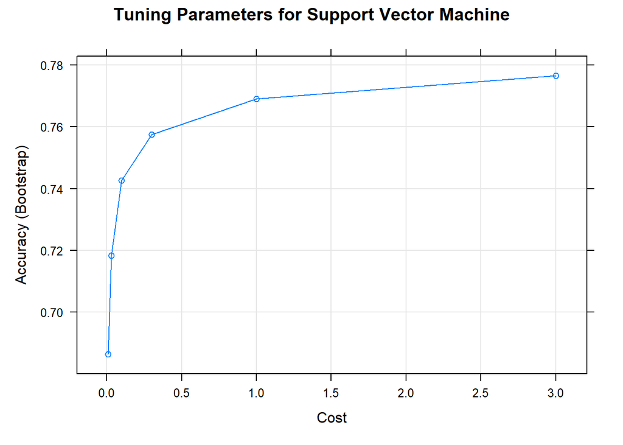

```r
#png(filename = "tuning_plot_svm.png", width = 600, height = 400)
plot(wSVM, main = "Tuning Parameters for Support Vector Machine")
```

```r
#dev.off()
```

```r
cl <- makePSOCKcluster(5) # init parallel processing
registerDoParallel(cl)


# a boosted classification tree for stacking
wGBM <- train(classe ~ ., method = "gbm",
              preProcess = c("center", "scale"),
              data = wTrain)

stopCluster(cl) # stop parallel processing
```

```r
pred_wGBM <- predict(wGBM, newdata = wTest)
confusionMatrix(pred_wGBM, wTest$classe)
```

```
## Confusion Matrix and Statistics
##
##           Reference
## Prediction    A    B    C    D    E
##          A 1098   34    0    0    0
##          B   14  709   15    0    6
##          C    1   11  661   24    4
##          D    2    1    7  617   13
##          E    1    4    1    2  698
##
## Overall Statistics
##
##                Accuracy : 0.9643
##                  95% CI : (0.958, 0.9699)
##     No Information Rate : 0.2845
##     P-Value [Acc > NIR] : < 2.2e-16
##
##                   Kappa : 0.9548
##
##  Mcnemar's Test P-Value : 0.0002211
##
## Statistics by Class:
##
##                      Class: A Class: B Class: C Class: D Class: E
## Sensitivity            0.9839   0.9341   0.9664   0.9596   0.9681
## Specificity            0.9879   0.9889   0.9877   0.9930   0.9975
## Pos Pred Value         0.9700   0.9530   0.9429   0.9641   0.9887
## Neg Pred Value         0.9936   0.9843   0.9929   0.9921   0.9929
## Prevalence             0.2845   0.1935   0.1744   0.1639   0.1838
## Detection Rate         0.2799   0.1807   0.1685   0.1573   0.1779
## Detection Prevalence   0.2886   0.1897   0.1787   0.1631   0.1800
## Balanced Accuracy      0.9859   0.9615   0.9770   0.9763   0.9828
```

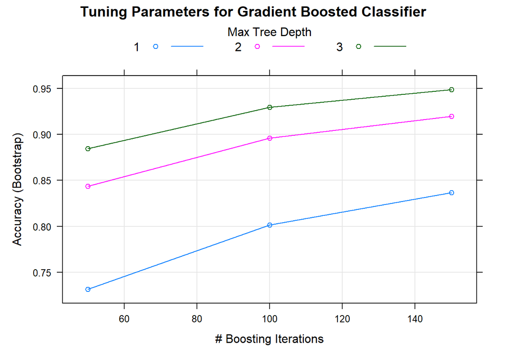

```r
#png(filename = "tuning_plot_gbm.png", width = 600, height = 400)
plot(wGBM, main = "Tuning Parameters for Gradient Boosted Classifier")
```

```r
#dev.off()
```

Ranking the four models on their performance on the test data, by their Kappa statistic, we have

- Random Forest: Kappa = 0.9887
- Radial Basis Function: Kappa = 0.9677
- Gradient Boosted Classifier: Kappa = 0.9548
- Support Vector Machine: Kappa = 0.7323

Well combine the best three models with a random forest to create a blended model. We will train the Combined model with each of the other models’ predictions on the test set. We will then use the Validation set to check the performance of the Combined model, and validate it with the other models.

```r
cl <- makePSOCKcluster(5) # init parallel processing
registerDoParallel(cl)

in_Train <- data.frame(classe = wTest$classe,
                       RF = pred_wRF,
                       RBF = pred_wRBF,
                       GBM = pred_wGBM)

wCOMB <- train(classe ~ ., method = "rf",
             tfControl = ctrl,
             preProcess = c("center", "scale"),
             tuneGrid = RFgrid,
             data = in_Train)

stopCluster(cl) # stop parallel processing
```

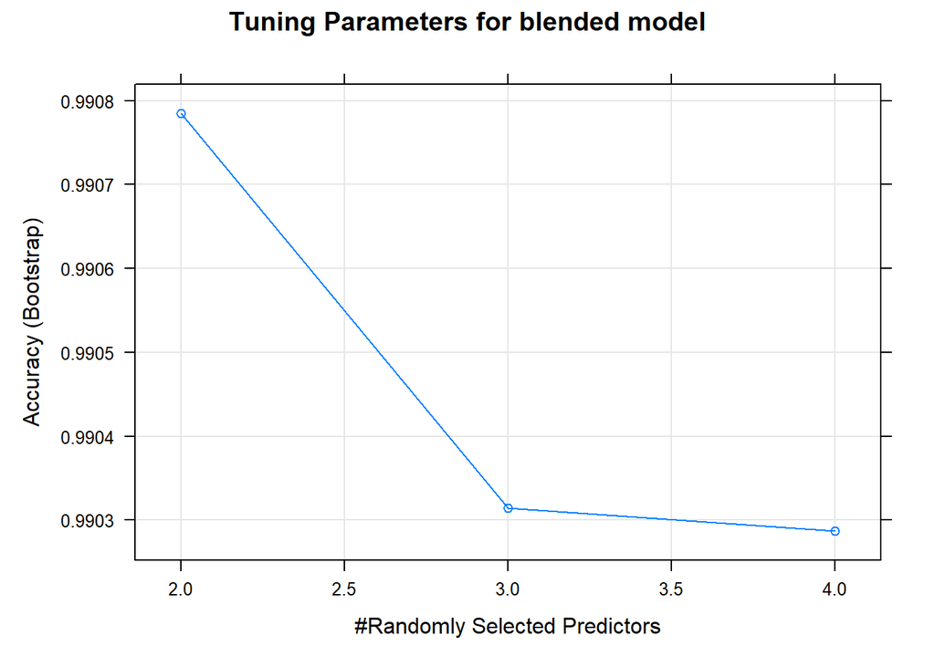

```r
#png(filename = "tuning_plot_comb.png", width = 600, height = 400)
plot(wCOMB, main = "Tuning Parameters for blended model")
```

```r
#dev.off()
```

```r
val_wRF <- predict(wRF, newdata = wVal)
confusionMatrix(val_wRF, wVal$classe)
```

```
## Confusion Matrix and Statistics
##
##           Reference
## Prediction    A    B    C    D    E
##          A 1336   11    0    0    0
##          B    3  897   13    0    0
##          C    0    2  806    7    0
##          D    0    1    2  764    2
##          E    0    0    0    0  863
##
## Overall Statistics
##
##                Accuracy : 0.9913
##                  95% CI : (0.9882, 0.9937)
##     No Information Rate : 0.2845
##     P-Value [Acc > NIR] : < 2.2e-16
##
##                   Kappa : 0.989
##
##  Mcnemar's Test P-Value : NA
##
## Statistics by Class:
##
##                      Class: A Class: B Class: C Class: D Class: E
## Sensitivity            0.9978   0.9846   0.9817   0.9909   0.9977
## Specificity            0.9967   0.9958   0.9977   0.9987   1.0000
## Pos Pred Value         0.9918   0.9825   0.9890   0.9935   1.0000
## Neg Pred Value         0.9991   0.9963   0.9961   0.9982   0.9995
## Prevalence             0.2845   0.1935   0.1744   0.1638   0.1838
## Detection Rate         0.2838   0.1906   0.1712   0.1623   0.1833
## Detection Prevalence   0.2862   0.1940   0.1731   0.1634   0.1833
## Balanced Accuracy      0.9972   0.9902   0.9897   0.9948   0.9988
```

This Random Forest model has given us a high accuracy, `0.9913`, on the validation set, with only `41` mis-classified observations. The Kappa statistic is `0.989`, which is fair to say that there is an extremely strong level of agreement in the classification of observations.

```r
val_wRBF <- predict(wRBF, newdata = wVal)
confusionMatrix(val_wRBF, wVal$classe)
```

```
## Confusion Matrix and Statistics
##
##           Reference
## Prediction    A    B    C    D    E
##          A 1327   20    0    2    0
##          B    6  881   18    0    0
##          C    1    5  794   30    3
##          D    4    1    9  737    5
##          E    1    4    0    2  857
##
## Overall Statistics
##
##                Accuracy : 0.9764
##                  95% CI : (0.9717, 0.9806)
##     No Information Rate : 0.2845
##     P-Value [Acc > NIR] : < 2.2e-16
##
##                   Kappa : 0.9702
##
##  Mcnemar's Test P-Value : 3.579e-05
##
## Statistics by Class:
##
##                      Class: A Class: B Class: C Class: D Class: E
## Sensitivity            0.9910   0.9671   0.9671   0.9559   0.9908
## Specificity            0.9935   0.9937   0.9900   0.9952   0.9982
## Pos Pred Value         0.9837   0.9735   0.9532   0.9749   0.9919
## Neg Pred Value         0.9964   0.9921   0.9930   0.9914   0.9979
## Prevalence             0.2845   0.1935   0.1744   0.1638   0.1838
## Detection Rate         0.2819   0.1872   0.1687   0.1566   0.1821
## Detection Prevalence   0.2866   0.1923   0.1770   0.1606   0.1836
## Balanced Accuracy      0.9923   0.9804   0.9785   0.9755   0.9945
```

This Radial Basis Function model has given us a high accuracy, `0.9764`, on the validation set, with only `111` mis-classified observations. The Kappa statistic is `0.9702`, which is fair to say that there is a very strong level of agreement in the classification of observations.

```r
val_wGBM <- predict(wGBM, newdata = wVal)
confusionMatrix(val_wGBM, wVal$classe)
```

```
## Confusion Matrix and Statistics
##
##           Reference
## Prediction    A    B    C    D    E
##          A 1315   33    0    1    0
##          B   15  851   37    6   10
##          C    4   22  774   19    2
##          D    4    1   10  744   14
##          E    1    4    0    1  839
##
## Overall Statistics
##
##                Accuracy : 0.9609
##                  95% CI : (0.955, 0.9663)
##     No Information Rate : 0.2845
##     P-Value [Acc > NIR] : < 2.2e-16
##
##                   Kappa : 0.9505
##
##  Mcnemar's Test P-Value : 2.02e-05
##
## Statistics by Class:
##
##                      Class: A Class: B Class: C Class: D Class: E
## Sensitivity            0.9821   0.9341   0.9428   0.9650   0.9699
## Specificity            0.9899   0.9821   0.9879   0.9926   0.9984
## Pos Pred Value         0.9748   0.9260   0.9428   0.9625   0.9929
## Neg Pred Value         0.9929   0.9842   0.9879   0.9931   0.9933
## Prevalence             0.2845   0.1935   0.1744   0.1638   0.1838
## Detection Rate         0.2794   0.1808   0.1644   0.1581   0.1782
## Detection Prevalence   0.2866   0.1952   0.1744   0.1642   0.1795
## Balanced Accuracy      0.9860   0.9581   0.9653   0.9788   0.9842
```

This Gradient Boosted model has given us a high accuracy, `0.9609`, on the validation set, with only `184` mis-classified observations. The Kappa statistic is `0.9505`, which is fair to say that there is a very strong level of agreement in the classification of observations.

```r
in_Val <- data.frame(classe = wVal$classe,
                       RF = val_wRF,
                       RBF = val_wRBF,
                       GBM = val_wGBM)

val_wCOMB <- predict(wCOMB, newdata = in_Val)
confusionMatrix(val_wCOMB, wVal$classe)
```

```
## Confusion Matrix and Statistics
##
##           Reference
## Prediction    A    B    C    D    E
##          A 1335   10    0    0    0
##          B    3  899   13    0    0
##          C    1    2  806    7    0
##          D    0    0    2  764    2
##          E    0    0    0    0  863
##
## Overall Statistics
##
##                Accuracy : 0.9915
##                  95% CI : (0.9884, 0.9939)
##     No Information Rate : 0.2845
##     P-Value [Acc > NIR] : < 2.2e-16
##
##                   Kappa : 0.9892
##
##  Mcnemar's Test P-Value : NA
##
## Statistics by Class:
##
##                      Class: A Class: B Class: C Class: D Class: E
## Sensitivity            0.9970   0.9868   0.9817   0.9909   0.9977
## Specificity            0.9970   0.9958   0.9974   0.9990   1.0000
## Pos Pred Value         0.9926   0.9825   0.9877   0.9948   1.0000
## Neg Pred Value         0.9988   0.9968   0.9961   0.9982   0.9995
## Prevalence             0.2845   0.1935   0.1744   0.1638   0.1838
## Detection Rate         0.2836   0.1910   0.1712   0.1623   0.1833
## Detection Prevalence   0.2857   0.1944   0.1734   0.1632   0.1833
## Balanced Accuracy      0.9970   0.9913   0.9896   0.9950   0.9988
```

Ultimately, the Combined model makes only an improvement of *one less error* than our strongest individual model, the Random Forest model. Thus, the added complexity of including this, on top of the other two models, frankly, is not worth the effort for scaling up and training on other datasets, when the Random Forest model already has near matched performance.

Still, we will use this combined model to make the predictions of the 20 test observations.

```r
# clean_dataframe is a helper function that repeats
# the same steps as for cleaning training data
test_sample <- clean_dataframe(testing, col_na, col_selection)

test_wRF <- predict(wRF, newdata = test_sample)
test_wRBF <- predict(wRBF, newdata = test_sample)
test_wGBM <- predict(wGBM, newdata = test_sample)

in_test <- data.frame(RF = test_wRF,
                      RBF = test_wRBF,
                      GBM = test_wGBM)

#predict(wCOMB, newdata = in_test)

# all 20 were predicted correctly
```

[output not shown]